### Telecommunication Industry Project

# Introduction

Welcome to this Jupyter notebook, a crucial part of your applied statistics learning experience. In this project, you'll be working with a dataset containing mobile phone prices and specifications.

## Dataset Columns Information

| Column | Description |
| --- | --- |
| PID | Unique identifier for the phone model |
| Blue | Bluetooth support (Yes/No) |
| Wi_Fi | WiFi support (Yes/No) |
| Tch_Scr | Touch screen support (Yes/No) |
| Ext_Mem | External Memory support (Yes/No) |
| Px_h | Number of pixels in the vertical axis of the phone |
| Px_w | Number of pixels in the horizontal axis of the phone |
| Scr_h | Height of the phone screen (in cm) |
| Scr_w | Width of the phone screen (in cm) |
| Int_Mem | Internal memory of the phone (in MB) |
| Bty_Pwr | Maximum battery energy (in mAh) |
| PC | Primary camera resolution (in MP) |
| FC | Front camera resolution (in MP) |
| RAM | Random access memory (in GB) |
| Depth | Depth of the mobile phone (in cm) |
| Weight | Weight of the mobile phone (in g) |
| Price | Selling price of the mobile phone (in rupees) |

## Task 1 - Load and study the data

Import the libraries that will be used in this notebook

```python
# Load "numpy" and "pandas" for manipulating numbers and data frames
# Load "matplotlib.pyplot" and "seaborn" for data visualisation
# Importing the basic libraries
import numpy as np
import pandas as pd
import matplotlib.pyplot as plt
import seaborn as sns
```

Load the csv file as pandas dataframe.

```python
# Read in the "Dataset" file as a Pandas Data Frame
df = pd.read_csv("Telecom Dataset.csv")
```

```python
# Take a brief look at the data
df
```

|  | PID | Blue | Wi_Fi | Tch_Scr | Ext_Mem | Px_h | Px_w | Scr_h | Scr_w | PC | FC | Int_Mem | Bty_Pwr | RAM | Depth | Weight | Price |
| --- | --- | --- | --- | --- | --- | --- | --- | --- | --- | --- | --- | --- | --- | --- | --- | --- | --- |
| 0 | AAB346A | yes | yes | no | no | 780 | 460 | 3 | 1 | 2 | 2 | 8 | 2800 | 2 | 7 | 320 | 3297 |
| 1 | AAC347I | yes | yes | no | no | 780 | 560 | 2 | 1 | 4 | 2 | 8 | 3000 | 2 | 7 | 280 | 4500 |
| 2 | BAB657J | no | yes | no | no | 840 | 720 | 2 | 1 | 4 | 2 | 8 | 3300 | 2 | 7 | 400 | 4898 |
| 3 | BBD456K | no | yes | yes | no | 1280 | 1120 | 5 | 3 | 6 | 2 | 32 | 3000 | 2 | 3 | 300 | 6900 |
| 4 | CCP761U | no | yes | yes | no | 1280 | 1080 | 4 | 3 | 6 | 2 | 16 | 3000 | 2 | 3 | 210 | 5600 |
| 5 | CCQ674K | yes | no | no | no | 1280 | 1080 | 4 | 3 | 6 | 4 | 8 | 2980 | 2 | 3 | 230 | 4990 |
| 6 | CTX123L | yes | no | yes | no | 1390 | 1080 | 6 | 3 | 8 | 4 | 32 | 3000 | 2 | 3 | 100 | 13400 |
| 7 | DFR256N | yes | no | no | no | 2880 | 2120 | 8 | 6 | 12 | 8 | 32 | 3200 | 2 | 3 | 80 | 15600 |
| 8 | DGS789M | yes | yes | yes | yes | 2580 | 1920 | 6 | 3 | 32 | 16 | 8 | 2800 | 6 | 3 | 120 | 27688 |
| 9 | ENG897N | yes | yes | yes | yes | 2580 | 1980 | 5 | 3 | 64 | 32 | 64 | 4380 | 4 | 3 | 150 | 23456 |
| 10 | EOP657N | yes | yes | yes | yes | 2580 | 1920 | 6 | 3 | 32 | 16 | 128 | 2800 | 4 | 4 | 210 | 35460 |
| 11 | ELS333L | yes | yes | yes | yes | 2580 | 1920 | 8 | 6 | 64 | 32 | 8 | 4500 | 8 | 4 | 150 | 43980 |
| 12 | ETT987D | no | yes | yes | yes | 2580 | 1980 | 6 | 5 | 64 | 32 | 64 | 4500 | 6 | 4 | 300 | 28700 |
| 13 | NAJ56GL | no | yes | yes | no | 2880 | 2120 | 6 | 5 | 32 | 16 | 64 | 2800 | 6 | 4 | 270 | 23600 |
| 14 | NBN329S | yes | yes | yes | yes | 2380 | 1820 | 5 | 3 | 16 | 8 | 8 | 2800 | 4 | 4 | 80 | 21972 |
| 15 | NSD450I | no | no | yes | yes | 1980 | 1760 | 10 | 8 | 16 | 16 | 128 | 3900 | 6 | 4 | 180 | 23456 |
| 16 | PDF768G | no | no | yes | yes | 2580 | 1980 | 8 | 6 | 64 | 32 | 128 | 3300 | 4 | 3 | 160 | 22650 |
| 17 | PDG234M | no | no | yes | yes | 2880 | 2120 | 8 | 6 | 8 | 8 | 64 | 2800 | 4 | 3 | 250 | 19806 |
| 18 | PEL111K | no | no | yes | yes | 1980 | 1760 | 8 | 6 | 12 | 4 | 8 | 4000 | 4 | 3 | 330 | 11388 |
| 19 | PNWD777L | no | no | yes | yes | 2880 | 2120 | 4 | 3 | 24 | 12 | 64 | 2800 | 4 | 3 | 200 | 14350 |
| 20 | POP857R | no | yes | yes | yes | 1980 | 1760 | 4 | 3 | 32 | 16 | 16 | 2800 | 4 | 3 | 150 | 24560 |
| 21 | QWR222Y | no | yes | yes | yes | 2580 | 1980 | 8 | 6 | 64 | 32 | 128 | 4400 | 4 | 3 | 160 | 21350 |
| 22 | QZR577O | no | yes | yes | yes | 1440 | 1280 | 4 | 3 | 8 | 8 | 64 | 2800 | 8 | 3 | 170 | 16999 |
| 23 | RAY344W | no | yes | yes | yes | 2880 | 2120 | 10 | 8 | 8 | 4 | 16 | 4800 | 8 | 3 | 170 | 18900 |
| 24 | RBZ451D | no | yes | yes | yes | 1440 | 1280 | 6 | 4 | 8 | 4 | 32 | 2800 | 8 | 3 | 150 | 17890 |
| 25 | SDO555G | no | yes | yes | yes | 2580 | 1980 | 6 | 3 | 64 | 32 | 64 | 4500 | 8 | 3 | 210 | 22000 |
| 26 | SET568R | no | yes | yes | yes | 1980 | 1280 | 5 | 3 | 8 | 4 | 128 | 4500 | 8 | 3 | 220 | 41320 |
| 27 | SFK567Y | yes | yes | yes | yes | 2580 | 2120 | 8 | 6 | 64 | 16 | 32 | 4300 | 8 | 3 | 200 | 49899 |
| 28 | SSD000L | yes | yes | yes | yes | 2580 | 2120 | 8 | 6 | 64 | 32 | 512 | 4200 | 8 | 3 | 270 | 36555 |
| 29 | SYL888P | no | yes | yes | yes | 2580 | 2120 | 8 | 6 | 64 | 16 | 256 | 5000 | 8 | 3 | 320 | 32459 |
| 30 | TVF078Y | yes | yes | yes | yes | 2580 | 2120 | 8 | 6 | 64 | 32 | 512 | 4860 | 8 | 3 | 90 | 29999 |
| 31 | TYQ109G | no | yes | yes | yes | 2580 | 2120 | 8 | 6 | 32 | 16 | 256 | 3300 | 8 | 3 | 110 | 45899 |
| 32 | TYS938L | yes | yes | yes | yes | 2580 | 2120 | 8 | 6 | 64 | 32 | 1024 | 4860 | 8 | 3 | 120 | 46777 |
| 33 | TYU444Q | no | yes | yes | yes | 2580 | 2120 | 8 | 6 | 64 | 32 | 128 | 2800 | 8 | 3 | 120 | 45680 |
| 34 | TYY453J | yes | yes | yes | yes | 2880 | 2120 | 6 | 3 | 64 | 32 | 128 | 4400 | 8 | 4 | 150 | 61750 |
| 35 | ULI999T | no | yes | yes | yes | 2440 | 2120 | 5 | 3 | 32 | 16 | 64 | 2800 | 8 | 4 | 210 | 42000 |
| 36 | UST000T | yes | yes | yes | yes | 2580 | 1980 | 10 | 8 | 64 | 32 | 32 | 3000 | 4 | 4 | 240 | 34589 |
| 37 | USZ111S | yes | yes | yes | yes | 2440 | 1980 | 5 | 3 | 48 | 32 | 128 | 4800 | 4 | 4 | 230 | 42300 |
| 38 | VWV532Y | yes | yes | yes | yes | 2580 | 1920 | 5 | 3 | 64 | 32 | 32 | 4860 | 8 | 4 | 310 | 39781 |
| 39 | VYI666I | yes | yes | yes | yes | 2440 | 1980 | 6 | 5 | 32 | 16 | 32 | 3200 | 4 | 4 | 180 | 33460 |
| 40 | WER765T | yes | yes | yes | yes | 2580 | 1980 | 5 | 3 | 64 | 32 | 128 | 3000 | 4 | 4 | 120 | 34780 |
| 41 | WUV902Y | yes | yes | yes | yes | 2580 | 1980 | 8 | 6 | 48 | 16 | 128 | 3400 | 4 | 3 | 140 | 28000 |
| 42 | WZB298K | yes | yes | yes | yes | 2580 | 1980 | 8 | 6 | 64 | 32 | 1024 | 5600 | 8 | 3 | 160 | 39000 |
| 43 | XKL901R | no | yes | yes | yes | 2580 | 1980 | 8 | 6 | 32 | 16 | 256 | 3900 | 4 | 3 | 210 | 54320 |
| 44 | XTL675G | yes | yes | yes | yes | 2580 | 1980 | 10 | 8 | 64 | 32 | 512 | 4560 | 8 | 3 | 260 | 51230 |
| 45 | XXV567F | no | yes | yes | yes | 2580 | 1980 | 8 | 6 | 64 | 32 | 64 | 2300 | 4 | 3 | 250 | 43990 |
| 46 | YTR67TY | yes | yes | yes | yes | 2580 | 1980 | 4 | 3 | 64 | 32 | 64 | 2800 | 4 | 3 | 200 | 56000 |
| 47 | ZDF789K | yes | yes | yes | no | 2880 | 2520 | 8 | 6 | 64 | 32 | 512 | 5600 | 12 | 2 | 80 | 84566 |
| 48 | ZEO567M | yes | yes | yes | no | 2880 | 2520 | 8 | 6 | 128 | 64 | 512 | 5600 | 12 | 2 | 110 | 88999 |
| 49 | ZZZ909X | yes | yes | yes | no | 2880 | 2520 | 8 | 6 | 128 | 64 | 1024 | 5600 | 12 | 2 | 130 | 149000 |

```python
# Get the dimensions of the dataframe
df.shape
```

```
(50, 17)
```

```python
# Get the row names of the dataframe

df.head()
```

|  | PID | Blue | Wi_Fi | Tch_Scr | Ext_Mem | Px_h | Px_w | Scr_h | Scr_w | PC | FC | Int_Mem | Bty_Pwr | RAM | Depth | Weight | Price |
| --- | --- | --- | --- | --- | --- | --- | --- | --- | --- | --- | --- | --- | --- | --- | --- | --- | --- |
| 0 | AAB346A | yes | yes | no | no | 780 | 460 | 3 | 1 | 2 | 2 | 8 | 2800 | 2 | 7 | 320 | 3297 |
| 1 | AAC347I | yes | yes | no | no | 780 | 560 | 2 | 1 | 4 | 2 | 8 | 3000 | 2 | 7 | 280 | 4500 |
| 2 | BAB657J | no | yes | no | no | 840 | 720 | 2 | 1 | 4 | 2 | 8 | 3300 | 2 | 7 | 400 | 4898 |
| 3 | BBD456K | no | yes | yes | no | 1280 | 1120 | 5 | 3 | 6 | 2 | 32 | 3000 | 2 | 3 | 300 | 6900 |
| 4 | CCP761U | no | yes | yes | no | 1280 | 1080 | 4 | 3 | 6 | 2 | 16 | 3000 | 2 | 3 | 210 | 5600 |

```python
# Get the column names of the dataframe
df.columns
```

```
Index(['PID', 'Blue', 'Wi_Fi', 'Tch_Scr', 'Ext_Mem', 'Px_h', 'Px_w', 'Scr_h',
       'Scr_w', 'PC', 'FC', 'Int_Mem', 'Bty_Pwr', 'RAM', 'Depth', 'Weight',
       'Price'],
      dtype='object')
```

```python
# Look at basic information about the dataframe
df.info()
```

```
<class 'pandas.core.frame.DataFrame'>
RangeIndex: 50 entries, 0 to 49
Data columns (total 17 columns):
 #   Column   Non-Null Count  Dtype
---  ------   --------------  -----
 0   PID      50 non-null     object
 1   Blue     50 non-null     object
 2   Wi_Fi    50 non-null     object
 3   Tch_Scr  50 non-null     object
 4   Ext_Mem  50 non-null     object
 5   Px_h     50 non-null     int64
 6   Px_w     50 non-null     int64
 7   Scr_h    50 non-null     int64
 8   Scr_w    50 non-null     int64
 9   PC       50 non-null     int64
 10  FC       50 non-null     int64
 11  Int_Mem  50 non-null     int64
 12  Bty_Pwr  50 non-null     int64
 13  RAM      50 non-null     int64
 14  Depth    50 non-null     int64
 15  Weight   50 non-null     int64
 16  Price    50 non-null     int64
dtypes: int64(12), object(5)
memory usage: 6.8+ KB
```

Observations:

There are 50 phones in the data set.

There are no missing values in the data set.

```python
df.isnull().sum()
```

```
PID        0
Blue       0
Wi_Fi      0
Tch_Scr    0
Ext_Mem    0
Px_h       0
Px_w       0
Scr_h      0
Scr_w      0
PC         0
FC         0
Int_Mem    0
Bty_Pwr    0
RAM        0
Depth      0
Weight     0
Price      0
dtype: int64
```

**Let's try some logical operators to filter the data.**

## Task 2 - Obtain the logical conditions for the features "Blue", "Wi_Fi", "Tch_Scr" and "Ext_Mem"

```python
# Get the feature names of the dataframe
df.columns
```

```
Index(['PID', 'Blue', 'Wi_Fi', 'Tch_Scr', 'Ext_Mem', 'Px_h', 'Px_w', 'Scr_h',
       'Scr_w', 'PC', 'FC', 'Int_Mem', 'Bty_Pwr', 'RAM', 'Depth', 'Weight',
       'Price'],
      dtype='object')
```

```python
# Creating a function to count the values of a variable
def count_values(dataframe, column_list):
    for column in column_list:
        print(f"Value counts for {column}:")
        print(dataframe[column].value_counts())
        print("-" * 20)
```

```python
l = ["Blue", "Wi_Fi", "Tch_Scr", "Ext_Mem"]
```

```python
count_values(df,l)
```

```
Value counts for Blue:
Blue
yes    27
no     23
Name: count, dtype: int64
--------------------
Value counts for Wi_Fi:
Wi_Fi
yes    42
no      8
Name: count, dtype: int64
--------------------
Value counts for Tch_Scr:
Tch_Scr
yes    45
no      5
Name: count, dtype: int64
--------------------
Value counts for Ext_Mem:
Ext_Mem
yes    38
no     12
Name: count, dtype: int64
--------------------
```

### The children want phones that have the following: Bluetooth, WiFi, touch screen and external memory support

### Create a logical condition for this situation and store the logical values as "con1"

```python
con1 = (df['Blue'] == 'yes') & (df['Wi_Fi'] == 'yes') & (df['Tch_Scr'] == 'yes') & (df['Ext_Mem'] == 'yes')
```

```python
con1.head()
```

```
0    False
1    False
2    False
3    False
4    False
dtype: bool
```

Observations:

The features "Blue", "Wi_Fi", "Tch_Scr" and "Ext_Mem" are binary in nature.

The children want all these features, so the logical condition "con1" has been obtained accordingly.

## Task 3 - Obtain the logical conditions for the features "Px_h" and "Px_w"

```python
# Get the feature names of the dataframe
l2= ['Px_h','Px_w']
```

```python
# Let's tackle these features: "Px_h", "Px_w"
count_values(df,l2)
```

```
Value counts for Px_h:
Px_h
2580    24
2880     9
1980     4
1280     3
2440     3
780      2
1440     2
840      1
1390     1
2380     1
Name: count, dtype: int64
--------------------
Value counts for Px_w:
Px_w
1980    15
2120    14
1920     4
1080     3
1760     3
1280     3
2520     3
460      1
560      1
720      1
1120     1
1820     1
Name: count, dtype: int64
--------------------
```

```python
# Create a new feature called "Px" which stores the total resolution of the screen
df['Px'] = df['Px_h'] + df['Px_w']
```

```python
df['Px'].value_counts()
```

```
Px
4560    14
4700     7
5000     6
4500     4
3740     3
5400     3
2360     2
2720     2
4420     2
1240     1
1340     1
1560     1
2400     1
2470     1
4200     1
3260     1
Name: count, dtype: int64
```

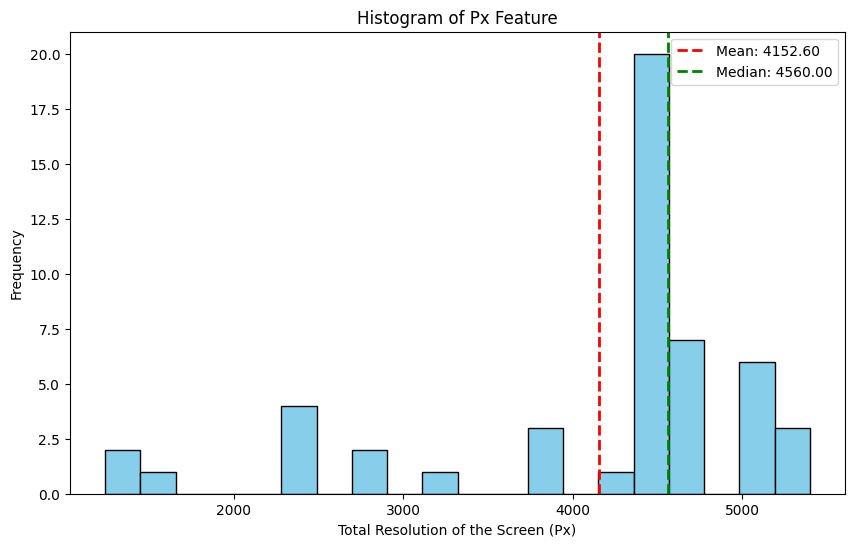

```python
# Create a histogram of the "Px" feature and also show the mean and the median
# Plotting the histogram
plt.figure(figsize=(10, 6))
plt.hist(df['Px'], bins=20, color='skyblue', edgecolor='black')
plt.title('Histogram of Px Feature')
plt.xlabel('Total Resolution of the Screen (Px)')
plt.ylabel('Frequency')

# Adding mean and median lines
mean_value = df['Px'].mean()
median_value = df['Px'].median()
plt.axvline(mean_value, color='red', linestyle='dashed', linewidth=2, label=f'Mean: {mean_value:.2f}')
plt.axvline(median_value, color='green', linestyle='dashed', linewidth=2, label=f'Median: {median_value:.2f}')
plt.legend()
plt.show()
```

### The children want phones that have good screen resolutions

### Consider the phones that have screen resolutions greater than or equal to the median value in the data set

### Create a logical condition for this situation and store the logical values as "con2"

```python
# Calculate the median screen resolution
median_resolution = df['Px'].median()

# Create the logical condition con2
con2 = df['Px'] >= median_resolution
```

```python
con2.head()
```

```
0    False
1    False
2    False
3    False
4    False
Name: Px, dtype: bool
```

Observations:

The features "Px_h" and "Px_w" are respectively the number of pixels in the phone screen in the vertical and horizontal axes.

The median has been selected as a threshold in this case.

In case it is too strict, we can choose the mean as a threshold.

# Task 4 - Obtain the logical conditions for the features "Scr_h" and "Scr_w"

```python
# Let's tackle these features: "Scr_h", "Scr_w"
l3 = ['Scr_h','Scr_w']
```

```python
count_values(df,l3)
```

```
Value counts for Scr_h:
Scr_h
8     20
6      9
5      8
4      6
10     4
2      2
3      1
Name: count, dtype: int64
--------------------
Value counts for Scr_w:
Scr_w
6    20
3    19
8     4
1     3
5     3
4     1
Name: count, dtype: int64
--------------------
```

```python
# Create a new feature called "Scr_d" which stores the length of the diagonal of the screen of the phone
df['Scr_d'] = np.sqrt(df['Scr_h']**2 + df['Scr_w']**2)
```

```python
df['Scr_d'].head()
```

```
0    3.162278
1    2.236068
2    2.236068
3    5.830952
4    5.000000
Name: Scr_d, dtype: float64
```

### Create a histogram of the "Scr_d" feature and also show the quartiles

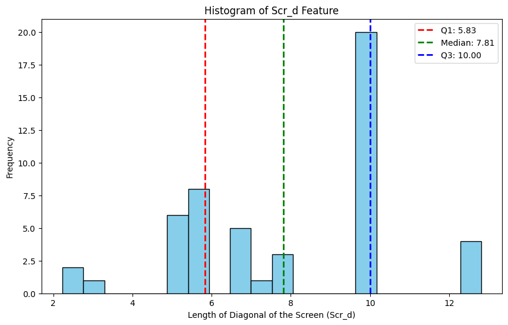

```python
# Plotting the histogram
plt.figure(figsize=(10, 6))
plt.hist(df['Scr_d'], bins=20, color='skyblue', edgecolor='black')
plt.title('Histogram of Scr_d Feature')
plt.xlabel('Length of Diagonal of the Screen (Scr_d)')
plt.ylabel('Frequency')

# Adding quartile lines
q25 = df['Scr_d'].quantile(0.25)
q50 = df['Scr_d'].quantile(0.50)
q75 = df['Scr_d'].quantile(0.75)
plt.axvline(q25, color='red', linestyle='dashed', linewidth=2, label=f'Q1: {q25:.2f}')
plt.axvline(q50, color='green', linestyle='dashed', linewidth=2, label=f'Median: {q50:.2f}')
plt.axvline(q75, color='blue', linestyle='dashed', linewidth=2, label=f'Q3: {q75:.2f}')
plt.legend()
plt.show()
```

### The children want phones that have very good screen sizes

### Consider the phones that have screen sizes greater than or equal to the upper quartile value in the data set

### Create a logical condition for this situation and store the logical values as "con3"

```python
# Calculate the upper quartile value for the Scr_d feature
upper_quartile = df['Scr_d'].quantile(0.75)

# Create the logical condition con3
con3 = df['Scr_d'] >= upper_quartile
```

```python
con3.head()
```

```
0    False
1    False
2    False
3    False
4    False
Name: Scr_d, dtype: bool
```

Observations:

The features "Scr_h" and "Scr_w" are respectively the height and the width of the phone screen.

We created a new feature called "Scr_d" which is essentially the length of the screen diagonal.

The upper quartile has been selected as a threshold in this case as the children were very particular on this point.

In case it is too strict, we can choose the mean or the median as a threshold.

# Task 5 - Obtain the logical conditions for the features "PC" and "FC"

```python
# Let's tackle these features: "PC", "FC"
l4 = ['PC','FC']
```

```python
count_values(df,l4)
```

```
Value counts for PC:
PC
64     21
32      8
8       6
6       3
4       2
12      2
16      2
48      2
128     2
2       1
24      1
Name: count, dtype: int64
--------------------
Value counts for FC:
FC
32    20
16    12
4      6
2      5
8      4
64     2
12     1
Name: count, dtype: int64
--------------------
```

### Create a histogram of the "PC" feature and also show the mean and the median

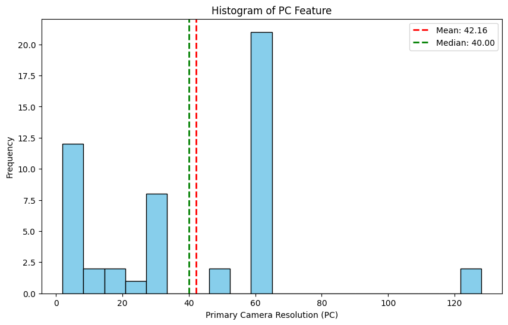

```python
# Plotting the histogram
plt.figure(figsize=(10, 6))
plt.hist(df['PC'], bins=20, color='skyblue', edgecolor='black')
plt.title('Histogram of PC Feature')
plt.xlabel('Primary Camera Resolution (PC)')
plt.ylabel('Frequency')

# Adding mean and median lines
mean_value = df['PC'].mean()
median_value = df['PC'].median()
plt.axvline(mean_value, color='red', linestyle='dashed', linewidth=2, label=f'Mean: {mean_value:.2f}')
plt.axvline(median_value, color='green', linestyle='dashed', linewidth=2, label=f'Median: {median_value:.2f}')
plt.legend()
plt.show()
```

### Create a histogram of the "FC" feature and also show the mean and the median

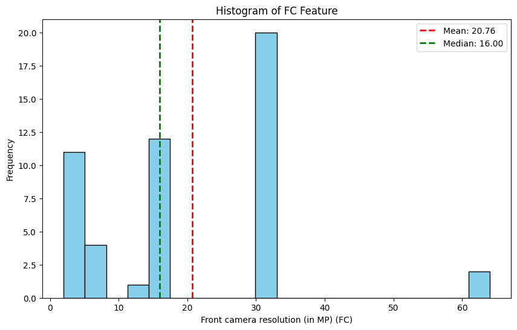

```python
# Plotting the histogram
plt.figure(figsize=(10, 6))
plt.hist(df['FC'], bins=20, color='skyblue', edgecolor='black')
plt.title('Histogram of FC Feature')
plt.xlabel('Front camera resolution (in MP) (FC)')
plt.ylabel('Frequency')

# Adding mean and median lines
mean_value = df['FC'].mean()
median_value = df['FC'].median()
plt.axvline(mean_value, color='red', linestyle='dashed', linewidth=2, label=f'Mean: {mean_value:.2f}')
plt.axvline(median_value, color='green', linestyle='dashed', linewidth=2, label=f'Median: {median_value:.2f}')
plt.legend()
plt.show()
```

### The children want phones that have good primary and front camera resolutions

### Consider the phones that have primary and front camera resolutions greater than or equal to their respective mean values

### Create a logical condition for this situation and store the logical values as "con4"

```python
# Calculate the mean values for PC and FC features
mean_pc = df['PC'].mean()
mean_fc = df['FC'].mean()

# Create the logical condition con4
con4 = (df['PC'] >= mean_pc) & (df['FC'] >= mean_fc)
```

```python
con4.head()
```

```
0    False
1    False
2    False
3    False
4    False
dtype: bool
```

Observations:

The features "PC" and "FC" are respectively the resolutions of the primary camera and the front camera.

The respective means have been selected as thresholds in this case.

In case it is too strict, we can choose the respective medians as thresholds.

# Task 6 - Obtain the logical conditions for the features "Int_Mem", "Bty_Pwr" and "RAM"

```python
# Let's tackle these features: "Int_Mem", "Bty_Pwr", "RAM"
l5 = ["Int_Mem", "Bty_Pwr", "RAM"]
count_values(df,l5)
```

```
Value counts for Int_Mem:
Int_Mem
64      10
128     10
8        8
32       8
512      5
16       3
256      3
1024     3
Name: count, dtype: int64
--------------------
Value counts for Bty_Pwr:
Bty_Pwr
2800    13
```

[output cut: 29 more lines]

### Create a histogram of the "Int_Mem" feature and also show the mean and the median

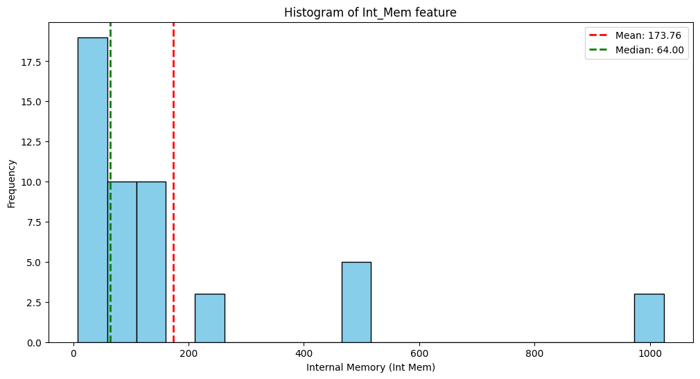

```python
plt.figure(figsize=[12,6])
plt.hist(df['Int_Mem'], bins=20,color='skyblue',edgecolor='black')
plt.title('Histogram of Int_Mem feature')
plt.xlabel('Internal Memory (Int Mem)')
plt.ylabel('Frequency')

mean_value = df['Int_Mem'].mean()
median_value = df['Int_Mem'].median()
plt.axvline(mean_value, color='red', linestyle='dashed', linewidth=2, label=f'Mean: {mean_value:.2f}')
plt.axvline(median_value, color='green', linestyle='dashed', linewidth=2, label=f'Median: {median_value:.2f}')
plt.legend()
plt.show()
```

### Create a histogram of the "Bty_Pwr" feature and also show the mean and the median

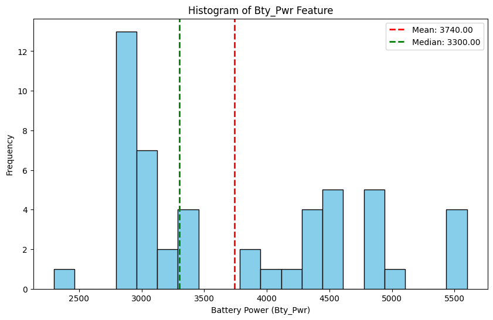

```python
# Plotting the histogram
plt.figure(figsize=(10, 6))
plt.hist(df['Bty_Pwr'], bins=20, color='skyblue', edgecolor='black')
plt.title('Histogram of Bty_Pwr Feature')
plt.xlabel('Battery Power (Bty_Pwr)')
plt.ylabel('Frequency')

# Adding mean and median lines
mean_value = df['Bty_Pwr'].mean()
median_value = df['Bty_Pwr'].median()
plt.axvline(mean_value, color='red', linestyle='dashed', linewidth=2, label=f'Mean: {mean_value:.2f}')
plt.axvline(median_value, color='green', linestyle='dashed', linewidth=2, label=f'Median: {median_value:.2f}')
plt.legend()
plt.show()
```

### Create a histogram of the "RAM" feature and also show the mean and the median

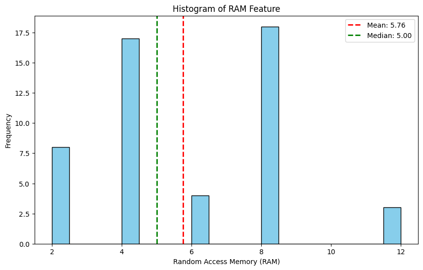

```python
# Plotting the histogram
plt.figure(figsize=(10, 6))
plt.hist(df['RAM'], bins=20, color='skyblue', edgecolor='black')
plt.title('Histogram of RAM Feature')
plt.xlabel('Random Access Memory (RAM)')
plt.ylabel('Frequency')

# Adding mean and median lines
mean_value = df['RAM'].mean()
median_value = df['RAM'].median()
plt.axvline(mean_value, color='red', linestyle='dashed', linewidth=2, label=f'Mean: {mean_value:.2f}')
plt.axvline(median_value, color='green', linestyle='dashed', linewidth=2, label=f'Median: {median_value:.2f}')
plt.legend()
plt.show()
```

### The children want phones that have good internal memory, battery power and RAM

### Consider the phones that have internal memory, battery power and RAM greater than or equal to their respective mean values

### Create a logical condition for this situation and store the logical values as "con5"

```python
# Calculate the mean values for Int_Mem, Bty_Pwr, and RAM features
mean_int_mem = df['Int_Mem'].mean()
mean_bty_pwr = df['Bty_Pwr'].mean()
mean_ram = df['RAM'].mean()

# Create the logical condition con5
con5 = (df['Int_Mem'] >= mean_int_mem) & (df['Bty_Pwr'] >= mean_bty_pwr) & (df['RAM'] >= mean_ram)
```

```python
con5.head()
```

```
0    False
1    False
2    False
3    False
4    False
dtype: bool
```

Observations

The features "Int_Mem", "Bty_Pwr" and "RAM" are respectively the internal memory, battery power and RAM of the phones.

The respective means have been selected as thresholds in this case.

.In case it is too strict, we can choose the respective medians as thresholds

# Task 7 - Obtain the logical conditions for the features "Depth" and "Weight"

```python
# Let's tackle these features: "Depth", "Weight"
l6 = ["Depth", "Weight"]
count_values(df,l6)
```

```
Value counts for Depth:
Depth
3    31
4    13
7     3
2     3
Name: count, dtype: int64
--------------------
Value counts for Weight:
Weight
210    5
150    5
120    4
160    3
200    3
```

[output cut: 22 more lines]

### Create a histogram of the "Depth" feature and also show the mean and the median

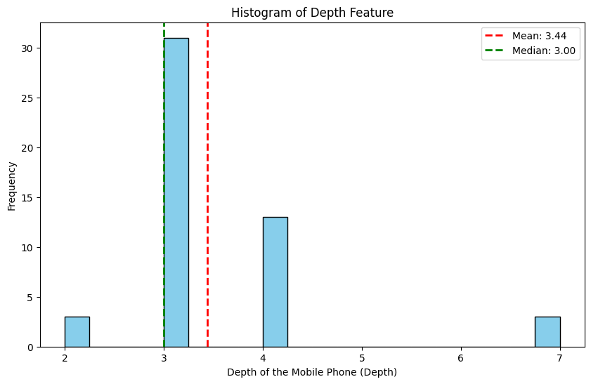

```python
# Plotting the histogram
plt.figure(figsize=(10, 6))
plt.hist(df['Depth'], bins=20, color='skyblue', edgecolor='black')
plt.title('Histogram of Depth Feature')
plt.xlabel('Depth of the Mobile Phone (Depth)')
plt.ylabel('Frequency')

# Adding mean and median lines
mean_value = df['Depth'].mean()
median_value = df['Depth'].median()
plt.axvline(mean_value, color='red', linestyle='dashed', linewidth=2, label=f'Mean: {mean_value:.2f}')
plt.axvline(median_value, color='green', linestyle='dashed', linewidth=2, label=f'Median: {median_value:.2f}')
plt.legend()
plt.show()
```

### Create a histogram of the "Weight" feature and also show the mean and the median

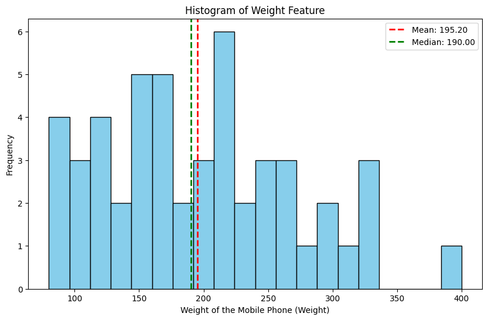

```python
# Plotting the histogram
plt.figure(figsize=(10, 6))
plt.hist(df['Weight'], bins=20, color='skyblue', edgecolor='black')
plt.title('Histogram of Weight Feature')
plt.xlabel('Weight of the Mobile Phone (Weight)')
plt.ylabel('Frequency')

# Adding mean and median lines
mean_value = df['Weight'].mean()
median_value = df['Weight'].median()
plt.axvline(mean_value, color='red', linestyle='dashed', linewidth=2, label=f'Mean: {mean_value:.2f}')
plt.axvline(median_value, color='green', linestyle='dashed', linewidth=2, label=f'Median: {median_value:.2f}')
plt.legend()
plt.show()
```

### The children want phones that are light weight and slim

### Consider the phones that have depth and weight less than or equal to the respective median values in the data set

### Create a logical condition for this situation and store the logical values as "con6"

```python
# Calculate the median values for Depth and Weight features
median_depth = df['Depth'].median()
median_weight = df['Weight'].median()

# Create the logical condition con6
con6 = (df['Depth'] <= median_depth) & (df['Weight'] <= median_weight)
```

```python
con6.head()
```

```
0    False
1    False
2    False
3    False
4    False
dtype: bool
```

Observations:

The features "Depth" and "Weight" are respectively the depth of the phone and the weight of the phone.

The respective medians have been selected as thresholds in this case.

In case it is too strict, we can choose the respective means as thresholds.